# Loan Data Exploration

## by (Andrew Samy Hanna)

## Investigation Overview

### In this investigation, I will discuss many important questions as:-

what kind of person is most likely to take a loan and for how long?

What is the commeon Loan amounts used?

What is the most used Monthly Loan Payment?

What factors affects the borrower’s APR and it's distribution?

What factors affects the Loan Original Amount?

What factors affect the ProsperScore?

## Dataset Overview

This document explores a dataset containing 113,937 loans with 81 variables on each loan, including loan amount, borrower rate (or interest rate), current loan status, borrower income, and many others.

## what kind of person is most likely to take a loan and for how long? (Employment Status and Duration)

Most of loans are only taken by th **employed** status.

Employment Duration is **inversely** proportional with the number of loans (most of loans are less than 150 months)

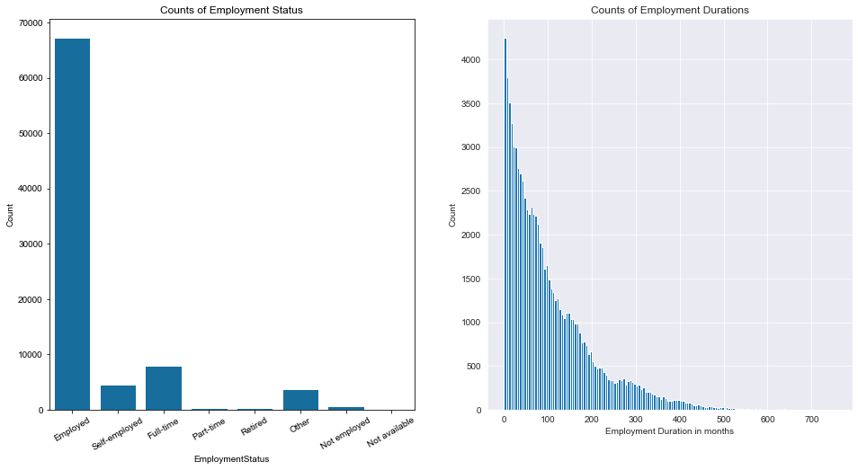

## The distribution of the borrower's Annual Percentage Rate (APR)

The distribution of APR has a large peak around 0.2, then a smaller one around 0.28

Also, there is a very high number of loans (more than 7000) with APR between 0.34 and 0.36.

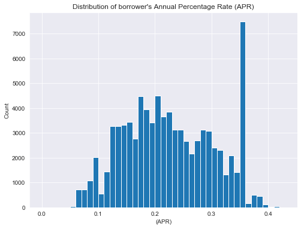

## What is the commeon Loan amounts used? (The distribution of Loan Original Amount)

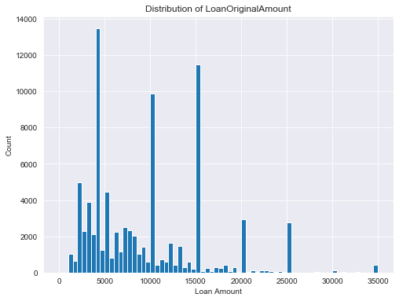

## What is the most used Monthly Loan Payment?

Also, there is a very high number of loans (more than 11000) with Monthly Loan Payment between 170 and 180.

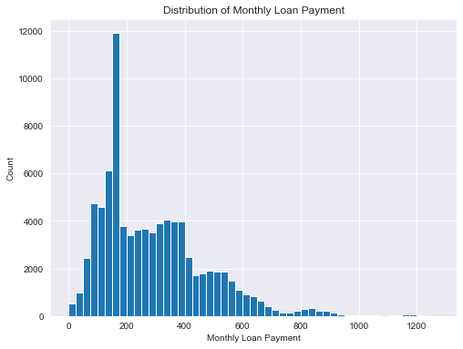

## Correlations:

### there is a positive correlation between:

LoanOriginalAmount - MonthlyLoanPayment

LoanOriginalAmount - ProsperScore

LoanOriginalAmount - AvailableBankcardCredit

### there is a negative correlation between:

BorrowerAPR - LoanOriginalAmount

BorrowerAPR - MonthlyLoanPayment

BorrowerAPR - ProsperScore

BorrowerAPR - AvailableBankcardCredit

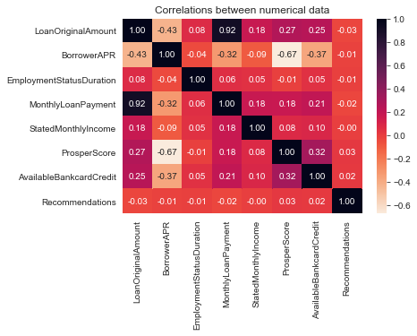

## What factors affect the ProsperScore?

ProsperScore is not affected by: the number of months

ProsperScore is directly proportional with: LoanOriginalAmount - AvailableBankcardCredit

ProsperScore is inversely proportional with: BorrowerAPR

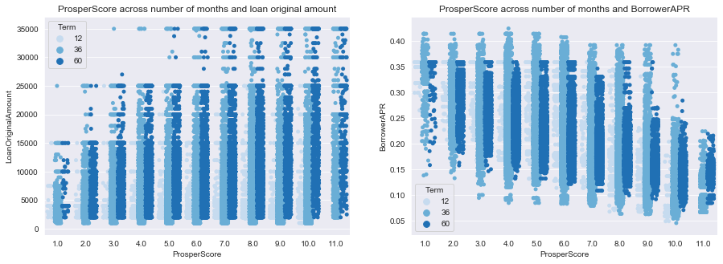